# How to use depth_estimation_module.py

depth_estimation_module.py is developed to estimate z-drift within an experiment and across experiments.

### Motivation:

- The brain of behaving mice moves and changes during two-photon calcium imaging. Thus, one needs to evaluate the extent of imaging plane movement during an experiment, especially in z-axis (z-drift).
- Often the goal of longitudinal imaging is to record from the same set of neurons across multiple days. Evaluation of imaging plane stability is critical for this goal (z-drift across sessions).

### Content:

depth_estimation_module.py contains multiple groups of functions.  
(As of 2022/12/07. These groups might be moved to another folder in the future.)

- General tools:
  - image_normalization_uint8(image, im_thresh = 0):
    - Normalize 2D image and convert to uint8. Prevent saturation. Used for image blending and saving to gif or mp4.
  - image_normalization_uint16(image, im_thresh = 0):
    - Normalize 2D image and convert to uint16. Prevent saturation. Used for CLAHE and saving to tiff files.
  - moving_average(data1d, window=10): self-explanatory.
  - get_frame_start_end(movie_len, segment_len):
    - Get the starting and end frame of each segment, given the length of movie and that of a segment.
  - im_blend(image, overlay, alpha):
    - Blend two images to show match or discrepancy
- General LIMS tools:
  - get_motion_correction_crop_xy_range(oeid):
    - Get x-y ranges to crop motion-correction frame rolling (currently assuming translation only)
  - check_correct_data(ophys_experiment_id, correct_Ly = 512, correct_Lx = 512):
    - Check the dimension of experiment images
  - get_image_size(ophys_experiment_id):
    - Get image size
  - get_correct_frame_rate(ophys_experiment_id):
    - Getting the correct frame rate, rather than fixed 11.0 from the metadata
  - find_first_experiment_id_from_ophys_container_id(ophys_container_id, valid_only = True):
    - Find the first experiment ID from the ophys container ID.
    - Assume experiment IDs are assigned chronologically.
  - find_first_experiment_id_from_ophys_experiment_id(ophys_experiment_id, valid_only=True):
    - Find the first experiment ID from the ophys experiment ID.
    - Assume experiment IDs are assigned chronologically.
  - check_if_ophys_experiment_id_in_ophys_container_id(ophys_experiment_id, ophys_container_id):
    - Check if ophys experiment ID is in the ophys container ID
- Query tools:
  - get_ophys_session_ids_for_mouse_id(mouse_id):
    - Get ophys session IDs for mouse ID
  - get_region_depth_ophys_experiment_id(ophys_experiment_id):
    - Get targeted region and depths for an ophys experiment ID
  - get_oeid_region_depth_for_ophys_session_id(ophys_session_id):
    - Get targeted region and depths for the ophys experiment IDs within an ophys session ID
- Get-path tools:
  - get_local_zstack_path(ophys_experiment_id):
    - Get local z-stack path.
  - get_storage_directory_path_for_ophys_experiment_id(ophys_experiment_id):
    - Get storage directory path for ophys_experiment_id
  - get_raw_h5_filepath(ophys_experiment_id): self-explanatory.
- Z-stack tools:
  - get_registered_zstack(ophys_experiment_id, ophys_experiment_dir):
    - Get within and between plane registered z-stack from an experiment.
    - If it was already processed, get it from the saved file. If not, process z-stack registration and save the results.
  - register_z_stack(ophys_experiment_id, number_of_z_planes=81, number_of_repeats=20):
    - Get registered z-stack, both within and between planes.
    - Can work for both taken by step protocol and loop protocol (need to be tested for the loop protocol)
  - average_reg_plane(images):
    - Get mean FOV of a plane after registration. Use phase correlation
  - reg_between_planes(stack_imgs):
    - Register between planes. Each plane with single 2D image.
    - Use phase correlation. Use median filtered images to calculate shift between neighboring planes.
    - Resulting image is not filtered.
  - med_filt_z_stack(zstack, kernel_size=5):
    - Get z-stack with each plane median-filtered
  - save_stack_to_video(stack, save_fn_path, frame_rate = 5, vmin=None, vmax=None):
    - Save image stack to video
- **Main z-drift and FOV matching codes:**
  - get_container_zdrift_df:
    - Get DataFrame about zdrift throughout the entire container.
    - Get the result if it was saved, unless rerun=True.
    - Save the result if save_df=True.
  - get_experiment_zdrift:
    - Get zdrift within an ophys experiment.
    - Register the mean FOV image to the z-stack using 2-step registration.
    - Then, apply the same transformation to segmented FOVs and calculated matched planes in each segment.
  - estimate_plane_from_ref_zstack:
    - Estimate matched plane of the FOV from the first z-stack.
    - Assume both inputs are cropped using the motion correction result (get_motion_correction_crop_xy_range)
    - Use phase correlation, and then StackReg.RIGID_BODY.
    - Apply CLAHE and uint16 conversion before RIGID_BODY registration.
    - Apply the StackReg result to original fov (after phase correlation registration).
  - fov_stack_register_phase_correlation:
    - Reigster FOV to each plane in the stack
  - fov_stack_register_rigid:
    - Find the best-matched plane index from the stack using rigid-body registration (StackReg)
    - First register the FOV to each plane in the stack
    - First pass: Pick the best-matched plane using pixel-wise correlation
    - Second pass: Using the transformed FOV to the first pass best-matched plane,

    sweep through all planes and refine the best-matched plane using correlation.  
    This fixes minor mis-match due to registration error.
  - get_segment_mean_images:
    - Get segmented mean images of an experiment
    - And save the result, in case the directory was specified.
  - twostep_fov_reg_zdrift:
    - FOV registration using translation (1st step) and rigid body (2nd step).
    - Use the result from previous registration (estimate_plane_from_ref_zstack).
- Plot
  - plot_container_zdrift_using_df
  - plot_experiment_zdrift
- For QC
  - plot_corrcoef_container
  - get_raw_segment_mean_images
  - register_between_mean_fovs
  - get_raw_segment_mean_images_registered
  - save_segment_fov_motion_crop
  - save_segment_fov
  - save_raw_segment_fov

### Dependency:

- numpy, pandas, matplotlib, os, h5py, skimage, scipy, cv2, imageio, tifffile, PIL, pathlib
- pystackreg
- mindscope_qc (developed to be implemented in mindscope_qc)
- visual_behavior_analysis (the goal is to remove this dependency)
- allensdk (to get the IDs)

### Caution:

Currently the base directory is set to \allen\programs\mindscope\workgroups\learning\ophys\zdrift (global_base_dir).  
This is base directory if other directory name is not specified in the function.  
In the future, this directory path will be changed to more appropriate path.

```python
import numpy as np
import pandas as pd
from pathlib import Path
from importlib import reload

import depth_estimation_module as dem
```

```python
# Getting the example datasets.
# From 8 pilot mice for LAMF project.
mouse_ids = [603892, 608368, 612764, 624942, 629294, 633532, 636496, 639224]
mouse_ids = [str(mid) for mid in mouse_ids]
pkl_dir = Path(r'\\allen\programs\mindscope\workgroups\learning\pipeline_validation'.replace('\\','/'))
lamf_dev_df = pd.read_pickle(pkl_dir / 'all_experiments.pkl')

test_df = lamf_dev_df.query("mouse_id.isin(@mouse_ids)")
ocid_list = np.sort(test_df.ophys_container_id.unique())
```

```python
# Running the whole container
reload(dem)
container_ind = 0
ocid = ocid_list[container_ind]

# Using default settings
zdrift_df = dem.get_container_zdrift_df(ocid, rerun=True)
# reference ophys experiment ID can be set by 'ref_oeid'. If not set, then use the first ophys experiment ID with the correct data dimension (assumed to be 512x512 by default.)
# Takes about 12 min for a container with 16 experiments, where z-stacks are already registered.
# If z-stack image are not processed or saved, it can take 1.5 - 3 hr.
```

```python
zdrift_df.head()
```

|  | ophys_experiment_id | zdrift | peak_cc | corrcoef | matched_plane_indice | translation_shift | rigid_tmat | ref_experiment_id | use_clahe | use_valid_pix_pc | use_valid_pix_sr |
| --- | --- | --- | --- | --- | --- | --- | --- | --- | --- | --- | --- |
| 0 | 1153099555 | [-1.5, 0.0] | [0.7021869663998014, 0.7170374959797542] | [[0.2104359385351708, 0.2119627171731063, 0.21... | [38, 40] | [-3.0, 0.0] | [[0.9999999953692814, 9.623636032949017e-05, 0... | 1153099555 | True | True | True |
| 1 | 1153662768 | [4.5, 3.0, 1.5, 1.5, 1.5, 1.5] | [0.695720066566682, 0.714876708996956, 0.70119... | [[0.18994065653400294, 0.19121138519078776, 0.... | [46, 44, 42, 42, 42, 42] | [0.0, 4.0] | [[0.9999999926208183, 0.00012148400447608, -0.... | 1153099555 | True | True | True |
| 2 | 1153920566 | [9.0, 9.0, 8.25, 6.75, 6.0, 6.0] | [0.6853855481491852, 0.6897205383500105, 0.690... | [[0.1495809197398303, 0.1497052169272514, 0.14... | [52, 52, 51, 49, 48, 48] | [-1.0, 5.0] | [[0.9999980504961544, 0.0019745895499064013, -... | 1153099555 | True | True | True |
| 3 | 1154288458 | [-10.5, -10.5, -8.25, -9.0, -9.0, -10.5] | [0.42335963226983303, 0.4118370169041988, 0.39... | [[0.2280258596397154, 0.23232550312780167, 0.2... | [26, 26, 29, 28, 28, 26] | [-16.0, 15.0] | [[0.9999970078359641, -0.0024462868022353305, ... | 1153099555 | True | True | True |
| 4 | 1154369474 | [-1.5, -1.5, -1.5, -0.75, -0.75, 0.0] | [0.5541726490824194, 0.5766674416470488, 0.582... | [[0.2231964324341853, 0.22530004063990305, 0.2... | [38, 38, 38, 39, 39, 40] | [18.0, 1.0] | [[0.9999999223814244, -0.00039400145326128457,... | 1153099555 | True | True | True |

```
(<Figure size 600x500 with 3 Axes>,
 <AxesSubplot:title={'center':'Container 1157145089'}, xlabel='Session #', ylabel='Relative depths ($\\mu$m)'>)
```

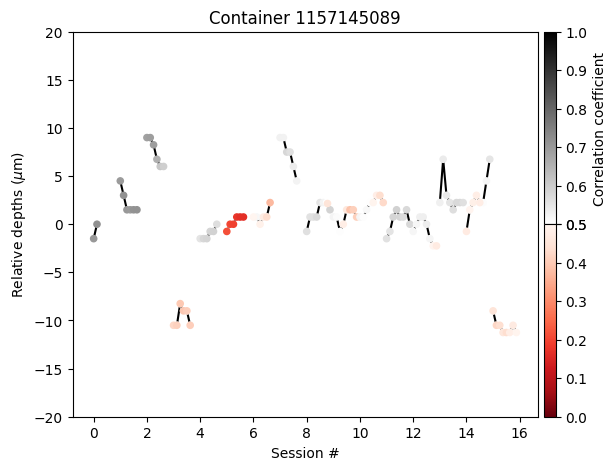

```python
# Plot the result
# This will automatically save the figure
dem.plot_container_zdrift_using_df(ocid, zdrift_df)
```

```python
# Running the container using specific reference ophys_experiment_id
# This will create h5 files for each experiment
# This will not overwrite the previous example, because the file names will be specific to the reference experiment ID.
ref_exp_ind = 11
oeids = zdrift_df.ophys_experiment_id.values
ref_oeid = oeids[ref_exp_ind]
zdrift_df = dem.get_container_zdrift_df(ocid, ref_oeid=ref_oeid, rerun=True)
```

```python
zdrift_df.head()
```

|  | ophys_experiment_id | zdrift | peak_cc | corrcoef | matched_plane_indice | translation_shift | rigid_tmat | ref_experiment_id | use_clahe | use_valid_pix_pc | use_valid_pix_sr |
| --- | --- | --- | --- | --- | --- | --- | --- | --- | --- | --- | --- |
| 0 | 1153099555 | [-1.5, -0.75] | [0.4575297873982508, 0.459267088054575] | [[0.14084535278380908, 0.14322773536307454, 0.... | [38, 39] | [-74.0, -20.0] | [[0.9999976014518394, 0.0021902261454535355, -... | 1156776068 | True | True | True |
| 1 | 1153662768 | [3.0, 3.0, 3.0, 3.0, 3.0, 3.0] | [0.5139295045469348, 0.5179994634959275, 0.500... | [[0.13079847516236492, 0.13242436249798778, 0.... | [44, 44, 44, 44, 44, 44] | [-71.0, -16.0] | [[0.9999961348136143, 0.0027803521057428995, -... | 1156776068 | True | True | True |
| 2 | 1153920566 | [9.0, 9.0, 8.25, 6.75, 6.75, 6.0] | [0.5083975567109775, 0.519430896049968, 0.5241... | [[0.0983894727779008, 0.09875371749241783, 0.0... | [52, 52, 51, 49, 49, 48] | [-72.0, -15.0] | [[0.9999943546803951, 0.003360149898477543, -0... | 1156776068 | True | True | True |
| 3 | 1154288458 | [-8.25, -8.25, -8.25, -8.25, -9.0, -10.5] | [0.43337439314106196, 0.41190938350666817, 0.3... | [[0.20331736674421058, 0.20686762853401172, 0.... | [29, 29, 29, 29, 28, 26] | [-83.0, -4.0] | [[0.9999947456745721, 0.0032417006721400265, -... | 1156776068 | True | True | True |
| 4 | 1154369474 | [-3.0, -2.25, -1.5, -1.5, 0.0, 0.0] | [0.44110805145298404, 0.44552746852191094, 0.4... | [[0.16504898913768104, 0.1678463012821838, 0.1... | [36, 37, 38, 38, 40, 40] | [-51.0, -18.0] | [[0.9999910293173777, 0.00423571537895605, -1.... | 1156776068 | True | True | True |

```
(<Figure size 600x500 with 3 Axes>,
 <AxesSubplot:title={'center':'Container 1157145089'}, xlabel='Session #', ylabel='Relative depths ($\\mu$m)'>)
```

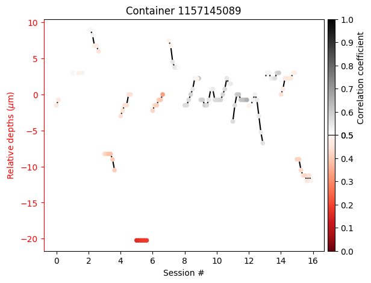

```python
# Plot the result
# This time, prevent saving the figure
dem.plot_container_zdrift_using_df(ocid, zdrift_df, save_figure=False)

# Failure in session #5 is more obvious in this plot.
```

```
(<Figure size 600x500 with 3 Axes>,
 <AxesSubplot:title={'center':'Container 1157145089'}, xlabel='Session #', ylabel='Relative depths ($\\mu$m)'>)
```

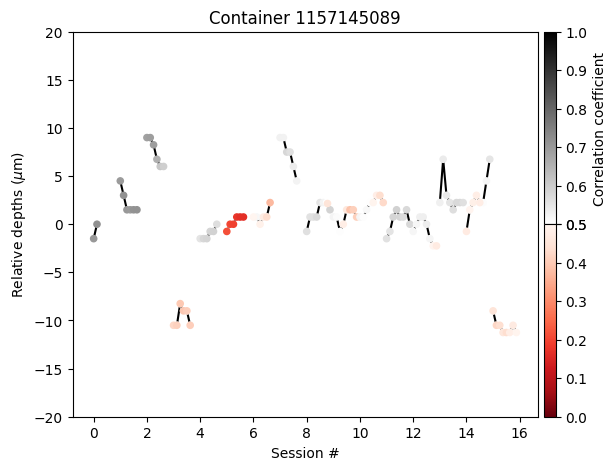

```python
# Plot the previous result again (default reference experiment ID)
# Since the data is saved, it will take about 10 s.
zdrift_df_old = dem.get_container_zdrift_df(ocid)
dem.plot_container_zdrift_using_df(ocid, zdrift_df_old, save_figure=False)
```

We can see the within and across session z-drifts are tightly correlated between calculations based on different reference session.  
In addition, we can see that the correlation coefficient gets higher when it gets closer to the reference experiment.  
This suggests gradual changes in either brain structure or set of active neurons day-to-day.

# Calculating z-drift in individual experiment

```python
# Calculate z-drift from its own z-stack (within-session z-drift)
exp_ind = 15
oeids = zdrift_df.ophys_experiment_id.values
oeid = oeids[exp_ind]
ref_oeid = oeid.copy()
matched_plane_indice, corrcoef, segment_reg_imgs, \
        mpi_mean_fov, cc_mean_fov, regimg_mean_fov, ref_zstack_crop, \
        rigid_tmat, translation_shift, ops = dem.get_experiment_zdrift(oeid, ref_oeid=ref_oeid)

# Takes about 1 min when using saved z-stack.
```

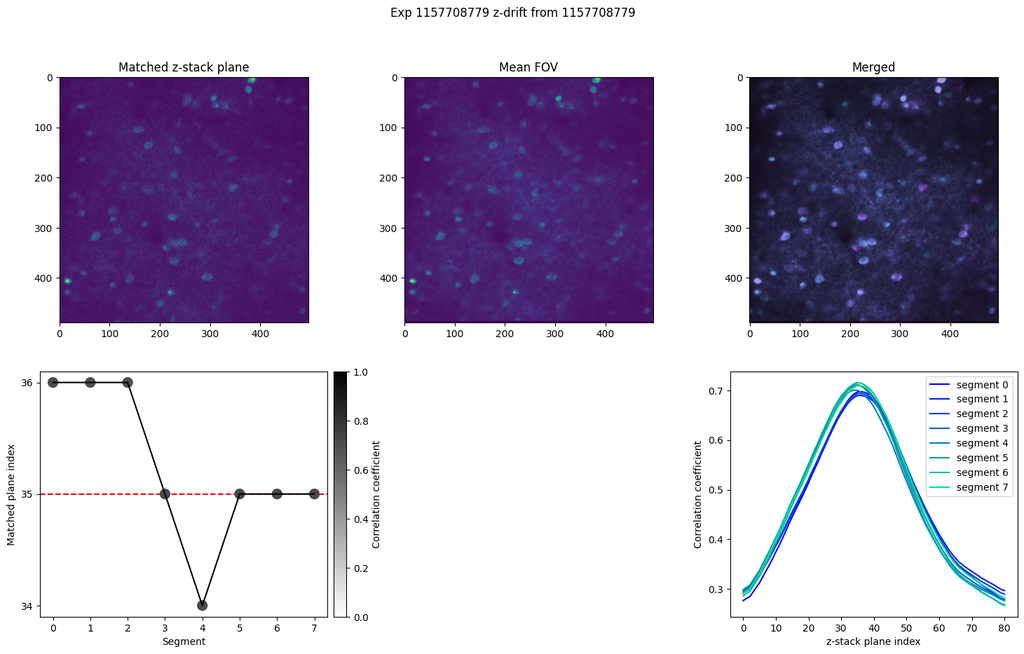

```python
# Plot the result
# For now, this figure is not saved.
# But the figure handle is returned
fig = dem.plot_experiment_zdrift(oeid, ref_oeid = ref_oeid)
```